# Data Sampling by applying vsp on Journal Citation Network

Sijia Fang

11/5/2020

## Introduction

When people want to learn a new technique, or understand a new field, looking for related references is a very common way to do it. However, this process can be extremely irritating. There could be tremendous amounts of paper related to that technique, describing how to apply or improve it under certain circumstances. It’s hard to understand these papers without the basic knowledge of the history about this technique.

This project aims to provide a way to analyze the developing process of certain statistical techniques. When a key word such as **lasso** is provided, a summary for it will be produced, including how it was proposed in the first place and when it became widely applied in different fields.

To attain this goal, we study [**Semantic Scholar Data**](http://s2-public-api-prod.us-west-2.elasticbeanstalk.com/corpus/). This is a large data set containing 220 million papers from various fields. To study the developing process of statistical techniques, the first step is filtering: we need to focus on mainstream academic journals that develop statistical methods or apply them.

This blog post illustrates how to achieve the filtering process via [**vsp**](https://arxiv.org/pdf/2004.05387.pdf) algorithm.

## Data

Semantic scholar dataset provides directed network $G_{paper} = (V_{paper},E_{paper})$ with every node $i$ in $V_{paper}$ represents a paper and $(i,j)\in E_{paper}$ if paper $i$ cite paper $j$. $G_p$ is extremely large and thus studying it directly is impractical. Luckily, $G_p$ is also sparse and can be aggregated as a weighted directed network $G_{journal} = (V_{journal},E_{journal})$ with every node $i$ in $V_{journal}$ represents a journal. $(i,j)\in E_{journal}$ if there exist paper in journal $i$ that cites paper in journal $j$, and $(i,j)$ is weighted by the number of citation from journal $i$ to journal $j$. $G_{journal}$ is still sparse but with moderate size, it contains approximately 100 thousand nodes. Notice that $G_{paper}$ contains 220 million nodes.

Our data is the adjacency matrix from $G_{journal}$. Our goal is to select top journals in statistics and other fields that frequently apply statistical tools.

## Method

**vsp** is designed to find underlying structures, it fits in many scenarios and here we focus on it’s application in Stochastic co-Blockmodel. As $A\approx ZBY^t$, $Y$ and $Z$ record two types of block membership, $B_{ij}$ represents how likely an edge from row-block $i$ to column-block $j$ will exist. Regrading the citation adjacency matrix, $Z$ gives a partition of journals based on how they cite others while $Y$ gives a partition of journals based on how they are cited by others. We will call them citing clusters and cited clusters in the following analysis. $B$ matrix reveals the citation pattern among groups.

## Result

### 1. Load the data and preprocessing

```r
library(Matrix)
library(vsp)
library(dplyr)
library(plotrix)
library(tidyverse)
library(tidytext)
library(tm)

# read data
edge <- read.csv("journalEdgeList.csv")
name <- read.csv("journalNames4EdgeList.csv")
name$y <- name$x

# create sparse adjancy matrix
Adj <- sparseMatrix(i = edge$from, j = edge$to, x = edge$weight,
                    dims = rep(dim(name)[1],2), dimnames = name)

# deal with repeated journal names
journal = str_replace_all(tolower(removePunctuation(rownames(Adj))), "[\r\n]" , " LineBreak ")
compress = sparse.model.matrix(~journal-1)
A = t(compress)%*%Adj%*%compress
A@x=sqrt(A@x)
rownames(A) <- sub("journal","",rownames(A))
colnames(A) <- sub("journal","",colnames(A))
uniqueJournals = rownames(A)
```

### 2. Simple analysis on indegree and outdegree

```r
# indegree
indegree <- colSums(A)
names(sort(indegree, decreasing = T)[1:10])
```

```
##  [1] "nature"
##  [2] "science"
##  [3] "proceedings of the national academy of sciences of the united states of america"
##  [4] "the new england journal of medicine"
##  [5] "plos one"
##  [6] "the journal of biological chemistry"
##  [7] "the lancet"
##  [8] "jama"
##  [9] "cell"
## [10] "circulation"
```

The top ten journals being cited are listed above, and they are all well-known journals in their fields.

```r
# outdegree
outdegree <- rowSums(A)
names(sort(outdegree, decreasing = T)[1:10])
```

```
##  [1] "plos one"
##  [2] "scientific reports"
##  [3] "arxiv"
##  [4] "international journal of molecular sciences"
##  [5] "proceedings of the national academy of sciences of the united states of america"
##  [6] "sensors basel  switzerland"
##  [7] "biorxiv"
##  [8] "biomed research international"
##  [9] "nature communications"
## [10] "ieee access"
```

The top ten journals that cite others most are more interesting. Actually, “arxiv” and “biorxiv” are not even journals, but they are sources for lots of papers, so it is not surprising that they cite others a lot.

### 3. Apply vsp to cluster the journals

```r
fa =  vsp(A, rank=50)
```

- 3.1 Clusters of statistics journals in both citing clusters and cited clusters.

```r
apply(fa$Y,2, function(x) uniqueJournals[order(-x)[1:20]])[,37]
```

```
##  [1] "journal of the american statistical association"
##  [2] "annals of statistics"
##  [3] "biometrika"
##  [4] "biometrics"
##  [5] "technometrics"
##  [6] "journal of the royal statistical society series bmethodological"
##  [7] "annals of mathematical statistics"
##  [8] "annals of probability"
##  [9] "journal of the royal statistical society series bstatistical methodology"
## [10] "statistics in medicine"
## [11] "stochastic processes and their applications"
## [12] "statistics  probability letters"
## [13] "journal of statistical planning and inference"
## [14] "journal of econometrics"
## [15] "comput stat data anal"
## [16] "journal of multivariate analysis"
## [17] "econometrica"
## [18] "annals of applied probability"
## [19] "journal of applied probability"
## [20] "probability theory and related fields"
```

```r
apply(fa$Z,2, function(x) uniqueJournals[order(-x)[1:20]])[,37]
```

```
##  [1] "arxiv probability"
##  [2] "arxiv statistics theory"
##  [3] "arxiv methodology"
##  [4] "comput stat data anal"
##  [5] "annals of statistics"
##  [6] "journal of statistical computation and simulation"
##  [7] "arxiv"
##  [8] "j multivar anal"
##  [9] "journal of the american statistical association"
## [10] "stochastic processes and their applications"
## [11] "journal of applied statistics"
## [12] "bernoulli"
## [13] "statistics in medicine"
## [14] "journal of econometrics"
## [15] "journal of statistical planning and inference"
## [16] "annals of applied probability"
## [17] "statistics  probability letters"
## [18] "annals of the institute of statistical mathematics"
## [19] "journal of nonparametric statistics"
## [20] "arxiv applications"
```

- 3.2 Observe $B$ matrix to see relationships between clusters

The cluster that best represent statistics journal in both citing clusters and cited clusters are the 37th, so we focus on 37th column and 37th row of $B$ matrix.

There is a strong diagonal pattern, indicating that if an edge comes from a node in the i-th sending block, then it probably goes to a node in the i-th receiving block.

If we focus on statistics block, it is clearly strongly connected to itself, but there are also other blocks that cites it or being cited by it.

```r
B <- as.matrix(fa$B)
range(B)
```

```
## [1] -9.875978e-07  4.949031e-06
```

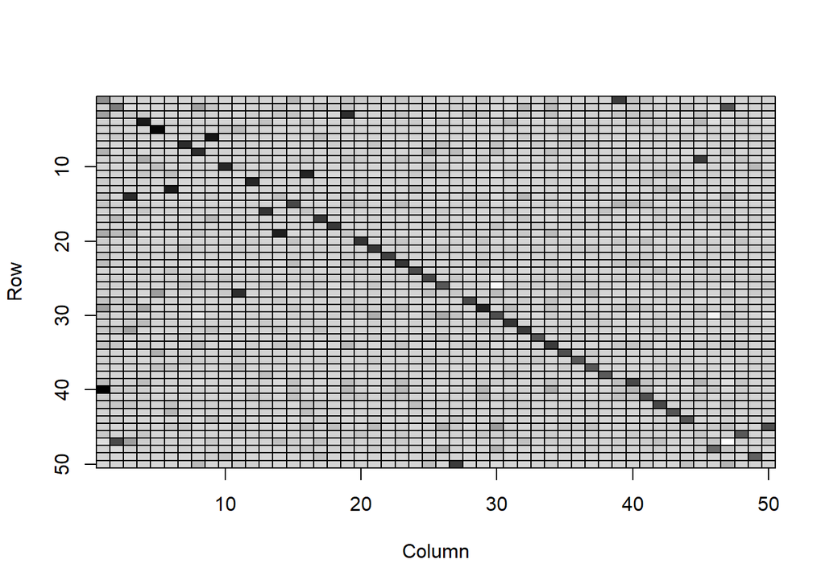

```r
B1 <- matrix(-1.299*10^(-6),50,50)
B1[,37] <- B[,37]
B1[37,] <- B[37,]
color2D.matplot(B, cs1=c(1,0),cs2=c(1,0),cs3=c(1,0))
```

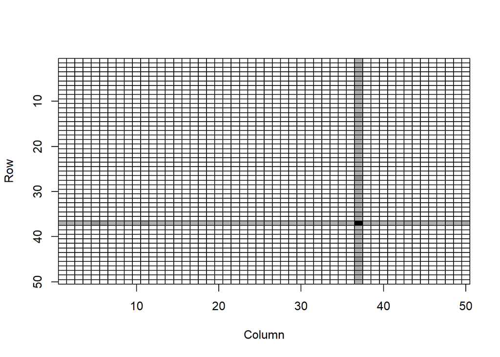

```r
color2D.matplot(B1, cs1=c(1,0),cs2=c(1,0),cs3=c(1,0))
```

Coefficient are ranked and ploted without the first one(statistics cluster itself), since the first one is way larger than the others.

For cited clusters, it’s clear that we should look into the first 6 clusters, for citing cluster, we may choose the first 4 or 6 clusters. Since we choose 6 clusters for cited cluster and it doesn’t harm to sample more data, we also take a closer look into the first 6 clusters for citing cluster.

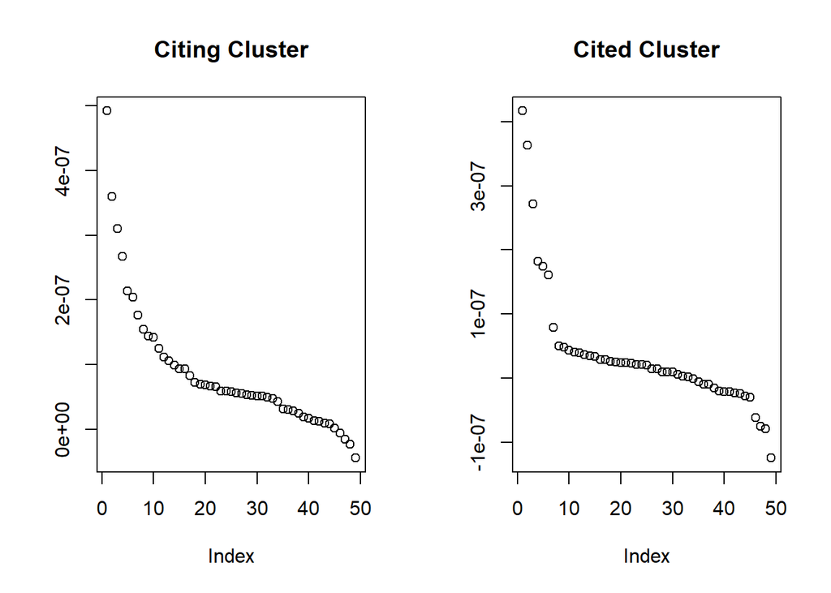

```r
CiteStat <- sort(fa$B[,37], decreasing = T)
StatCite <- sort(fa$B[37,], decreasing = T)
par(mfrow = c(1,2))
plot(CiteStat[-1], ylab = '', main = 'Citing Cluster') # first 7 (including itself)
plot(StatCite[-1], ylab = '', main = 'Cited Cluster') # first 7 (including itself)
```

```r
CiteStatSample <- CiteStat[2:7]
StatCiteSample <- StatCite[2:7]
```

Now let’s find out the topics (like statistics for the 37th cluster) of these clusters and top journals in them. Here We use [bff](https://github.com/RoheLab/vsp/blob/master/R/bff.R) to extract best feature of these clusters.

Best feature function will highlight words (tokens) in journal names that can best describe this cluster.

According to the results, statistical journals are highly associated with journals in math, computer science and economics. Now we can get a list of journal names and sample papers based on them.

```r
CiteStatIndex <- as.numeric(sub("z","",names(CiteStatSample)))
StatCiteIndex <- as.numeric(sub("y","",names(StatCiteSample)))
text_df <- tibble(id = 1:length(uniqueJournals),
                  text = uniqueJournals)
# this does a lot of processing!
#  to lower, remove @ # , .
#  often these make sense on a first cut.
#  worth revisiting before "final results"!
tt  = text_df %>% unnest_tokens(word, text)
dt = cast_sparse(tt, id, word)
cs = colSums(dt)
dt = dt[,cs>3]
bff(fa$Z, dt,10)[,CiteStatIndex]
```

```
##       [,1]           [,2]           [,3]           [,4]
##  [1,] "mathematical" "control"      "economics"    "j"
##  [2,] "arxiv"        "engineering"  "economic"     "comput"
##  [3,] "analysis"     "transactions" "review"       "math"
##  [4,] "mathematics"  "j"            "finance"      "arxiv"
##  [5,] "numerical"    "syst"         "policy"       "theory"
##  [6,] "mechanics"    "comput"       "financial"    "discret"
##  [7,] "equations"    "fuzzy"        "journal"      "comb"
##  [8,] "siam"         "management"   "econometrics" "combinatorics"
##  [9,] "math"         "cybernetics"  "economy"      "sci"
## [10,] "comput"       "oper"         "of"           "appl"
##       [,5]           [,6]
##  [1,] "processing"   "robotics"
##  [2,] "signal"       "control"
##  [3,] "vision"       "automation"
##  [4,] "image"        "robots"
##  [5,] "on"           "ieee"
##  [6,] "ieee"         "intelligent"
##  [7,] "pattern"      "ieeersj"
##  [8,] "recognition"  "conference"
##  [9,] "conference"   "on"
## [10,] "transactions" "transactions"
```

```r
bff(fa$Y, dt,10)[,StatCiteIndex]
```

```
##       [,1]            [,2]           [,3]           [,4]           [,5]
##  [1,] "mathematical"  "mathematical" "economics"    "j"            "accounting"
##  [2,] "mathematics"   "mathematics"  "economic"     "comput"       "finance"
##  [3,] "arxiv"         "siam"         "review"       "math"         "financial"
##  [4,] "geometry"      "physics"      "journal"      "theory"       "economics"
##  [5,] "mathematica"   "analysis"     "finance"      "comb"         "journal"
##  [6,] "algebra"       "mechanics"    "of"           "mathematical" "business"
##  [7,] "topology"      "numerical"    "econometrics" "discret"      "review"
##  [8,] "differential"  "applied"      "economy"      "foundations"  "of"
##  [9,] "mathematische" "equations"    "policy"       "mathematics"  "management"
## [10,] "mathã"         "math"         "political"    "siam"         "banking"
##       [,6]
##  [1,] "oper"
##  [2,] "comput"
##  [3,] "res"
##  [4,] "syst"
##  [5,] "transactions"
##  [6,] "j"
##  [7,] "management"
##  [8,] "transportation"
##  [9,] "appl"
## [10,] "fuzzy"
```

## Visualization

Here we provide a visualization for citation relationships between the selected journal groups. Flow between two blocks describes the left cluster citing the right, and the wider flow means more citations. This is an interactive graph, move the mouse over flows and explore more!

```r
library(tidyverse)
library(viridis)
library(patchwork)
library(hrbrthemes)
library(circlize)
library(networkD3)
data <- as.data.frame(B[c(37,CiteStatIndex), c(37,StatCiteIndex)])
rownames(data) <- c("statistics","math","operation control and management","economics","combinatorial analysis","signal processing","robotics/AI")
colnames(data) <- c("statistics","math:algebra","math & physics/pde","economics", "combinatorial analysis","accounting/finance","operation control and management")
data <- data*10^9
data_long <- data %>%
  rownames_to_column %>%
  gather(key = 'key', value = 'value', -rowname) %>%
  filter(value > 0)
colnames(data_long) <- c("source", "target", "value")
data_long$target <- paste(data_long$target, " ", sep="")

# From these flows we need to create a node data frame: it lists every entities involved in the flow
nodes <- data.frame(name=c(as.character(data_long$source), as.character(data_long$target)) %>% unique())

# With networkD3, connection must be provided using id, not using real name like in the links dataframe.. So we need to reformat it.
data_long$IDsource=match(data_long$source, nodes$name)-1
data_long$IDtarget=match(data_long$target, nodes$name)-1

# prepare colour scale
ColourScal ='d3.scaleOrdinal() .range(["#FDE725FF","#B4DE2CFF","#6DCD59FF","#35B779FF","#1F9E89FF","#26828EFF","#31688EFF","#3E4A89FF","#482878FF","#440154FF"])'

# Make the Network
sankeyNetwork(Links = data_long, Nodes = nodes,
              Source = "IDsource", Target = "IDtarget",
              Value = "value", NodeID = "name",
              sinksRight=FALSE, colourScale=ColourScal, nodeWidth=40, fontSize=13, nodePadding=20)
```

[interactive chart not shown]

## code to get journal list

In the following work, we will limit the journal that we study into a smaller range according to the analysis in this post. More specific, we’ll only explore the journals that are strongly associated to the statistical journals, namely journals in the selected groups (which citing the statistics cluster and being cited by statistics cluster). We can obtain the journals using the code below.

```r
# n is the number of journals we want in each clusters
n = 10
Jname <- as.vector(apply(fa$Z,2, function(x) uniqueJournals[order(-x)[1:n]])[,c(37,CiteStatIndex)])
Jname <- c(Jname,as.vector(apply(fa$Y,2, function(x) uniqueJournals[order(-x)[1:n]])[,c(37,StatCiteIndex)]))
Jname <- unique(Jname)
```